# 7002HW2

# Q1 - Awards Data

The data awards.csv contains the number of awards earned by students at one high school. We consider two predictors: • prog: the type of program in which the student is enrolled (3 categories of general, academic or vocational). • math: a continuous variable representing students’ scores on their math final exam. Use the following to load data and address the questions using Poisson regression. awards <- read.csv(‘awards.csv’) awards$prog <- factor(awards$prog, levels=c(“General”,“Academic”,“Vocational”))

## 1. Is mean roughly equal to variance for each type of program?

```r
awards  <- read.csv('awards.csv')
awards$prog <- factor(awards$prog, levels = c("General","Academic","Vocational"))

dim(awards)
```

```
## [1] 200   4
```

```r
names(awards)
```

```
## [1] "id"         "num_awards" "prog"       "math"
```

```r
str(awards)
```

```
## 'data.frame':    200 obs. of  4 variables:
##  $ id        : int  45 108 15 67 153 51 164 133 2 53 ...
##  $ num_awards: int  0 0 0 0 0 0 0 0 0 0 ...
##  $ prog      : Factor w/ 3 levels "General","Academic",..: 3 1 3 3 3 1 3 3 3 3 ...
##  $ math      : int  66 66 69 67 65 67 71 65 58 71 ...
```

```r
apply(awards, 2, function(x) sum(is.na(x)))
```

```
##         id num_awards       prog       math
##          0          0          0          0
```

```r
grouped_awards <- awards %>%
  group_by(prog) %>%
  summarise(
    mean_awards = mean(num_awards),
    variance_awards = var(num_awards)
  )

grouped_awards
```

```
## # A tibble: 3 × 3
##   prog       mean_awards variance_awards
##   <fct>            <dbl>           <dbl>
## 1 General           0.2            0.164
## 2 Academic          1              1.63
## 3 Vocational        0.24           0.268
```

Mean is only roughly equal to variance for “General’ and ‘Vocational’ programmes only.

## 2. Consider model_1 “num_awards ~ math + prog” and model_2 “num_awards ~ math”. Use “anova(model_2, model_1, test=’Chisq’)” to test significance of “prog”.

```r
model_1 <- glm(num_awards~math+prog, family = 'poisson', data = awards)
summary(model_1)
```

```
##
## Call:
## glm(formula = num_awards ~ math + prog, family = "poisson", data = awards)
##
## Coefficients:
##                Estimate Std. Error z value Pr(>|z|)
## (Intercept)    -7.00093    0.89706  -7.804 5.98e-15 ***
## math            0.07015    0.01060   6.619 3.63e-11 ***
## progAcademic    1.08386    0.35825   3.025  0.00248 **
## progVocational  0.36981    0.44107   0.838  0.40179
## ---
## Signif. codes:  0 '***' 0.001 '**' 0.01 '*' 0.05 '.' 0.1 ' ' 1
##
## (Dispersion parameter for poisson family taken to be 1)
##
##     Null deviance: 287.67  on 199  degrees of freedom
## Residual deviance: 189.45  on 196  degrees of freedom
## AIC: 373.5
##
## Number of Fisher Scoring iterations: 6
```

```r
model_2 <- glm(num_awards~math, family = 'poisson', data = awards)
summary(model_2)
```

```
##
## Call:
## glm(formula = num_awards ~ math, family = "poisson", data = awards)
##
## Coefficients:
##              Estimate Std. Error z value Pr(>|z|)
## (Intercept) -7.487672   0.831277  -9.007   <2e-16 ***
## math         0.086166   0.009679   8.902   <2e-16 ***
## ---
## Signif. codes:  0 '***' 0.001 '**' 0.01 '*' 0.05 '.' 0.1 ' ' 1
##
## (Dispersion parameter for poisson family taken to be 1)
##
##     Null deviance: 287.67  on 199  degrees of freedom
## Residual deviance: 204.02  on 198  degrees of freedom
## AIC: 384.08
##
## Number of Fisher Scoring iterations: 6
```

```r
anova(model_2, model_1, test='Chisq')
```

```
## Analysis of Deviance Table
##
## Model 1: num_awards ~ math
## Model 2: num_awards ~ math + prog
##   Resid. Df Resid. Dev Df Deviance  Pr(>Chi)
## 1       198     204.02
## 2       196     189.45  2   14.572 0.0006852 ***
## ---
## Signif. codes:  0 '***' 0.001 '**' 0.01 '*' 0.05 '.' 0.1 ' ' 1
```

P-value is less than 0.05, hence ‘Prog’ is statistically significant.

## 3. How many more wards do we expect one student to get in the “Academic” program compared to the “General” program with a math score of 90?

```r
data1.3 = data.frame(math = c(90,90), prog = c('Academic','General'))
data1.3$pred = predict(model_1, newdata = data1.3, type = 'response')
data1.3[1,3] - data1.3[2,3]
```

```
## [1] 0.9838483
```

Hence we expect one student to get 0.984 more wards in the “Academic” program compared to the “General” program with a math score of 90.

# Q2 - Lung Cancer Data

The data.txt file is a 12625 x 56 matrix; each column (row) of the matrix corresponds to the individual case (gene). Among the 56 cases,  
Columns 1~20: pulmonary carcinoid samples (Carcinoid); Columns 21~33: colon cancer metastasis samples (Colon); Columns 34~50: normal lung samples (Normal); Columns 51~56: small cell carcinoma samples (SmallCell). Before the following analyses, please first center each row of the data, i.e. remove the mean of each row and transpose the matrix.

## Q2.1 Principal Component Analysis

- Apply PCA to the transposed matrix to extract the first three principal components. Be careful with outliers.
- Use the scree plot to explain whether these three components are sufficient.
- Plot pair-wise scatterplots and use the sample labels (Carcinoid, Colon, Normal, SmallCell) to explain the plots.

```r
lungcancer <- read.table('lungcancer.txt')
data = data.frame(t(scale(lungcancer)))
```

```r
pca <- prcomp(data, scale=TRUE)
pca_ <- pca$x[, (1:3)]
pca_
```

```
##            PC1         PC2         PC3
## V1  -48.903383  32.8669083 -13.7586077
## V2  -55.734096  36.6213206   6.6056629
## V3   -8.199113  57.8495258  56.1400452
## V4  -31.258415  41.3115174  43.9313988
## V5  -31.457758  36.7156352   5.3556425
## V6  -35.562217  38.7362911   5.9540780
## V7  -40.000598  42.9162516  12.7077191
## V8  -53.242089  29.6046951 -13.9470544
## V9  -32.035946  46.6649427  27.8056480
## V10 -48.840606  26.0305710  -5.4829746
## V11 -62.604389   4.7587427 -18.8456589
## V12 -61.139954  16.8156827 -24.3595331
## V13 -74.542991   3.8905609 -28.4687720
## V14 -28.033297  32.4982478  36.4232958
## V15 -31.069158  56.3309821  21.5001559
## V16 -23.743832  57.2907892  24.6716048
## V17 -58.207856  37.8854230   1.7968435
## V18 -62.311357  -3.3479983 -52.7108959
## V19 -52.571346  40.1619769  -2.5618747
## V20 -73.372766  18.7261944  -9.1708271
## V21  53.197492  -8.0878696  56.0324174
## V22 -14.646337 -62.3897037   2.9608989
## V23  -8.879103 -39.0520190  26.8623876
## V24 -30.995063 -75.9074172  27.9382457
## V25   6.328854 -51.3476967  58.7323818
## V26 -39.606058 -55.1218396 -14.3296879
## V27  18.180879 -52.2234398  35.0979720
## V28   9.911290 -59.5572488  19.2007533
## V29 -13.126480 -62.7306988 -25.6333901
## V30  19.420081 -36.9320706  45.7924373
## V31 -24.080270 -75.7103513  -1.4271348
## V32 -37.081468 -68.1868161   2.6344749
## V33 -34.996337 -52.6080798  10.2000957
## V34  55.228964 -23.2909399   8.8888051
## V35  71.266102  12.1182024 -33.9586898
## V36  79.143158  34.1163187  -2.2449451
## V37  48.057943  12.4585598 -48.9686508
## V38  64.194226  14.4799213 -34.3549932
## V39  70.302521  11.9252509   4.9936288
## V40  86.092343  26.5729726   0.6262608
## V41  87.370620  22.2809579  -0.3295433
## V42  77.766928  20.8646864 -13.1965654
## V43  73.163933   2.9580264 -14.0462466
## V44  40.438344  -5.3904189 -37.3437709
## V45  58.802423 -15.3612827  31.0307569
## V46  64.932755  -4.2531441   6.1952276
## V47  85.158966  32.2509531 -17.7720504
## V48  48.417381  -9.2305649  -4.2956317
## V49  50.434247   9.5713274 -23.7928458
## V50  53.059142   2.9246943 -42.3876463
## V51  30.419805  -6.3485534  -7.7444115
## V52 -15.856089  -0.6941325  22.2079066
## V53 -37.520499 -26.1211171 -28.9263049
## V54   2.631281  -7.9251963   2.7660638
## V55 -28.463027 -35.4133342 -38.9430071
## V56 -55.837781 -22.9661963 -46.0510944
```

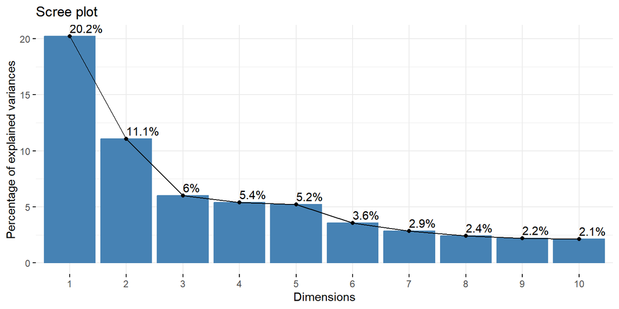

```r
library(factoextra)
fviz_eig(pca, addlabels = TRUE)
```

These three components explain 37.3% variance, which is enough to explain these three components

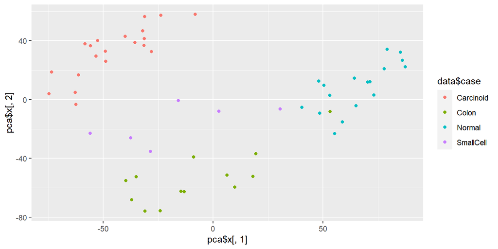

```r
data$case<-c(rep('Carcinoid',20),rep('Colon',13),rep('Normal',17),rep('SmallCell',6))
ggplot(data = data, aes(x = pca$x[,1], y = pca$x[,2], color = data$case)) + geom_point()
```

## Q2.2 Nominal Logistic Regression, LDA and SVM

Consider the first three principal components in Q2.1 as predictors, and the sample labels(Carcinoid, Colon, Normal, SmallCell) as the categorical response.  
- Perform nominal logistics regression, LDA and SVM. - Present, compare and discuss the results.

```r
data_2 = data.frame(pca$x[, (1:3)], case = c(rep('Carcinoid',20), rep('Colon',13), rep('Normal',17), rep('SmallCell',6)))
data_2$case = factor(data_2$case)
model_log =  multinom(case ~., data = data_2)
model_lad =  lda(case ~ .,data_2)
model_svm =  svm(case ~ .,data_2 )
```

```r
pred1 = predict(model_log)
sum(pred1 == data_2$case ) / nrow(data_2)
```

```
## [1] 1
```

```r
pred2 = predict(model_lad)
sum(pred2$class == data_2$case ) / nrow(data_2)
```

```
## [1] 0.9821429
```

```r
pred3 = predict(model_svm)
sum(pred3 == data_2$case ) / nrow(data_2)
```

```
## [1] 0.9821429
```

According to the result, Nominal logistics regression perform better than LDA and SVM.

## Q2.3 Clustering

Consider the first three principal components in Q2.1 as predictors. - Perform K-means and hierarchical clustering analyses using the first three principal components. - Use the sample labels to discuss whether the two analyses are reasonable.

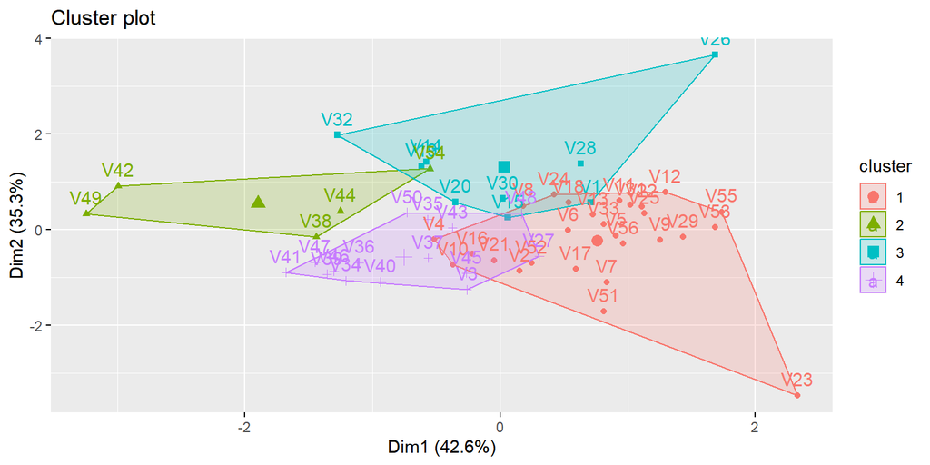

```r
fit.km = kmeans(data[1:3], 4)
data$kmeans =  fit.km$cluster
fviz_cluster(fit.km, data[1:3])
```

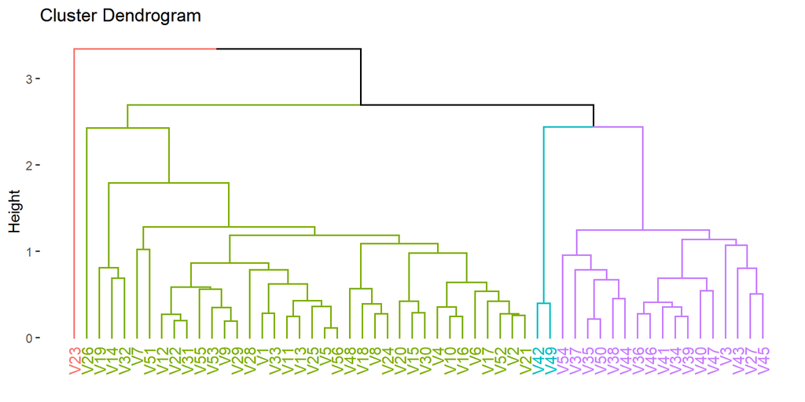

```r
d = dist(data[1:3])
fit.c <- hclust(d, method = "average")
fviz_dend(fit.c, k=4)
```

The two analyses are not very reasonable. 1 to 20, 21 to 33, 34 to 50 and 51 to 56 are not classified into one category. The classification of kmean and hierarchical clustering is very different from the actual results.